# Notes on KIPP College Match Algorithm

Version: 2  
Updated: 8/8/19

## Reverse-Engineering

#### System Inputs

- **Unweighted GPA**: Float value between 1.50 and 4.30.
- **ACT**: Integer value between 11 and 36.
- **SAT (EBRW + M)***: Integer value between 590 and 1600. Mapped to an ACT score via a lookup table.

Following are not used for core functionality but just enable filtering of the result set:

- **Annual Family Income**
  - 0 - \$30K
  - \$30K - \$48K
  - \$48K - \$75K
- **City**: A list of cities is available on the **Lat and Long** sheet

#### System Outputs

- A list of colleges categorized into **Likely+**, **Likely**, **Target**, and **Reach**.
  - **Likely+**: 80% to 100% odds of admission + High Grad Rate
  - **Likely**: 80% to 100% odds of admission
  - **Target**: 50% to 79% odds of admission
  - **Reach**: 15% to 49% odds of admission
- The **Unlikely** designation is not included in the KIPP system, but is added for schools with less than 15% odds of admission.
  - **Unlikely**: <14% odds of admission

## The Algorithm

Consider example of a Harvard applicant with a 4.25 GPA and a 29 ACT.

$$Logit_{Harvard}=GPA_{coef}*GPA + ACT_{coef}*(ACT-ACT_{adj})+intercept$$

$$Logit_{Harvard}=(4.2009)(4.25)+(0.2751)(29-32)-17.92$$

$$Logit_{Harvard}=-0.891475$$

The "Odds" of admission is calculated from this "Logit" term.

$$Odds_{Harvard}=\frac{e^{logit}}{1+e^{logit}}$$

$$Odds_{Harvard}=29.08\%$$

In this example, the **29.08%** "Odds" given to this Harvard applicant would place him in the **Reach category** for Harvard.

Other examples in the table printed below.

```python
import pandas as pd
import numpy as np
import matplotlib.pyplot as plt
#from matplotlib import rc
#rc('font',**{'family':'sans-serif','sans-serif':['Helvetica']})
## for Palatino and other serif fonts use:
#rc('font',**{'family':'serif','serif':['Palatino']})
#rc('text', usetex=True)
original = pd.read_excel('FY19 WE Student Match Tool Updated (original).xlsm',
                         sheet_name='AllColleges',
                         header=2)
c = original.copy()
```

```python
c['GPA'] = 4.25
c['ACT'] = 29
c = c[['GPA','ACT','Name (Copy)','Match Code',
       'GPAcoef','ACT-coef','Intercept','AdjACT','Logit','Odds']]
c.columns = ['GPA','ACT','Name','Match Code',
             'GPA_coef','ACT_coef','Intercept','ACT_adj','Logit','Odds']
```

```python
sub = (c[c['Name'].isin(['Harvard University',
                         'University of California-Los Angeles',
                         'Cal Poly State University-San Luis Obispo',
                         'California State University-Bakersfield',
                         'Chapman University'])]
       .reset_index(drop=True))
sub.head()
```

|  | GPA | ACT | Name | Match Code | GPA_coef | ACT_coef | Intercept | ACT_adj | Logit | Odds |
| --- | --- | --- | --- | --- | --- | --- | --- | --- | --- | --- |
| 0 | 4.25 | 29 | Harvard University | 7.0 | 4.2009 | 0.2751 | -17.92000 | 32.0 | -0.891475 | 29.080553 |
| 1 | 4.25 | 29 | University of California-Los Angeles | 7.0 | 4.2009 | 0.2751 | -17.92000 | 30.0 | -0.341275 | 41.549980 |
| 2 | 4.25 | 29 | Chapman University | 5.0 | 2.8488 | 0.3200 | -9.05000 | 25.0 | 4.337400 | 98.709817 |
| 3 | 4.25 | 29 | Cal Poly State University-San Luis Obispo | 7.0 | 4.2009 | 0.2751 | -17.92000 | 28.0 | 0.208925 | 55.204209 |
| 4 | 4.25 | 29 | California State University-Bakersfield | 3.0 | 3.7965 | 0.5073 | -8.09091 | 18.0 | 13.624515 | 99.999879 |

Note: The $GPA_{coef}$, $ACT_{coef}$, $Intercept$, and $ACT_{adj}$ appear to be KIPP property or derived from some other document. Where these values come from is unclear based on the Excel file we have. The data is simply in the file as raw data, like a copy-paste with values only.

It is also unclear how our data could be used to update these values. Based upon the way these parameters are labeled, they appear to be terms taken from a linear regression based on applications data that KIPP or some other organization have.

#### Coefficients, Intercepts and Concepts

This section breaks down the distribution of the coefficients, intercepts, and ACT adjustments just discussed.

The two coefficients and the intercept appear to group with one another. ACT_adj does not group with the rest of them.

```python
coeff = c[['Match Code','GPA_coef','ACT_coef','Intercept']].copy()
coeff = (pd.DataFrame(pd.pivot_table(coeff,
                                     index=['Match Code','GPA_coef','ACT_coef','Intercept'],
                                     aggfunc=len))
         .rename(columns={0:'College Count'}))
coeff
```

| Match Code | GPA_coef | ACT_coef | Intercept | College Count |
| --- | --- | --- | --- | --- |
| 0.0 | 1.0000 | 1.0000 | 1.000000 | 81 |
| 1.0 | 2.9197 | 0.4148 | -5.092858 | 5 |
| 2.0 | 2.7910 | 0.4580 | -5.312678 | 64 |
|  | 3.7965 | 0.5073 | -8.090910 | 1 |
| 3.0 | 2.7910 | 0.4580 | -5.312678 | 4 |
|  | 2.8488 | 0.3200 | -9.050000 | 2 |
|  | 3.3385 | 0.3992 | -8.252064 | 13 |
|  | 3.7965 | 0.5073 | -8.090910 | 620 |
| 4.0 | 2.7910 | 0.4580 | -5.312678 | 8 |
|  | 2.8488 | 0.3200 | -9.050000 | 14 |
|  | 3.3385 | 0.3992 | -8.252064 | 258 |
|  | 3.7965 | 0.5073 | -8.090910 | 3 |
| 5.0 | 2.8488 | 0.3200 | -9.050000 | 74 |
|  | 3.3385 | 0.3992 | -8.252064 | 3 |
|  | 4.7749 | 0.3220 | -17.950000 | 2 |
| 6.0 | 2.8488 | 0.3200 | -9.050000 | 8 |
|  | 4.7749 | 0.3220 | -17.950000 | 68 |
| 7.0 | 2.8488 | 0.3200 | -9.050000 | 1 |
|  | 4.2009 | 0.2751 | -17.920000 | 44 |

#### ACT Adjustments

```python
act = c[['Match Code','ACT_adj']].copy()
act = (pd.DataFrame(pd.pivot_table(act,
                                   index=['ACT_adj'],
                                   aggfunc=len))
       .rename(columns={'Match Code':'College Count'}))
act
```

| ACT_adj | College Count |
| --- | --- |
| 13.0 | 2.0 |
| 14.0 | 3.0 |
| 15.0 | 13.0 |
| 16.0 | 30.0 |
| 17.0 | 75.0 |
| 18.0 | 134.0 |
| 19.0 | 170.0 |
| 20.0 | 170.0 |
| 21.0 | 149.0 |
| 22.0 | 108.0 |
| 23.0 | 88.0 |
| 24.0 | 50.0 |
| 25.0 | 46.0 |
| 26.0 | 34.0 |
| 27.0 | 23.0 |
| 28.0 | 24.0 |
| 29.0 | 19.0 |
| 30.0 | 21.0 |
| 31.0 | 13.0 |
| 32.0 | 15.0 |
| 33.0 | 1.0 |
| 34.0 | 1.0 |

All other parameters in the tool appear to be used to filter the various colleges based on items like

- 6-year African-American/Hispanic Grad rate,
- number of undergrads,
- cost to attend,
- distance from current location, etc.

The data that back up the tool appears fairly robust, but clearly broken for some schools.

The core "College Matching" functionality is captured above.

## Create Graphs

Solve for Values of Logit and for the crucial Odds Thresholds

$$\frac{e^{logit}}{1+e^{logit}}=Odds$$

```python
import sympy as sy
import numpy as np
import matplotlib.pyplot as plt
```

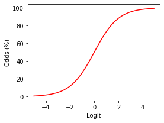

```
When Logit =  -5, Odds = 1 %
When Logit =  -4, Odds = 2 %
When Logit =  -3, Odds = 5 %
When Logit =  -2, Odds = 12 %
When Logit =  -1, Odds = 27 %
When Logit =  0, Odds = 50 %
When Logit =  1, Odds = 73 %
When Logit =  2, Odds = 88 %
When Logit =  3, Odds = 95 %
When Logit =  4, Odds = 98 %
When Logit =  5, Odds = 99 %
```

```python
def f(x):
    return np.exp(x)/(1+np.exp(x))*100

x = np.arange(-5,5,0.05)
plt.figure(figsize=(4,3))
plt.xlabel('Logit')
plt.ylabel('Odds (%)')
plt.plot(x, f(x), 'r-')
plt.show()
for n in range(-5, 6, 1):
    print('When Logit =  {}, Odds = '.format(n) + str(int(round(f(n)))) + " %")
```

```python
x = sy.Symbol('x')
```

```python
logit_likely = float(sy.solve((sy.exp(x)/(1+sy.exp(x)))-.8,x)[0])
logit_target = float(sy.solve((sy.exp(x)/(1+sy.exp(x)))-.5,x)[0])
logit_reach = float(sy.solve((sy.exp(x)/(1+sy.exp(x)))-.15,x)[0])
```

```python
print('Likely Odds: 80%, logit = ' + str(logit_likely))
print('Target Odds: 50%, logit = ' + str(logit_target))
print('Reach Odds:  15%, logit = ' + str(logit_reach))
```

```
Likely Odds: 80%, logit = 1.3862943611198906
Target Odds: 50%, logit = 0.0
Reach Odds:  15%, logit = -1.7346010553881064
```

### Plot the curves for these various values of Logit

Independent Variable: **GPA**, because it is difficult to dramatically impact at time of college applications.  
Dependent Variable: **ACT**, because it can be improved.

$$(GPA_{coef})(GPA) + (ACT_{coef})(ACT-ACT_{adj})+intercept-logit = 0$$

$$ACT = ACT_{adj} + \frac{logit - intercept - (GPA_{coef})(GPA)}{ACT_{coef}}$$

```python
sub2 = (sub[['Name','GPA_coef','ACT_coef','Intercept','ACT_adj']]
        .set_index('Name'))
sub2
```

| Name | GPA_coef | ACT_coef | Intercept | ACT_adj |
| --- | --- | --- | --- | --- |
| Harvard University | 4.2009 | 0.2751 | -17.92000 | 32.0 |
| University of California-Los Angeles | 4.2009 | 0.2751 | -17.92000 | 30.0 |
| Chapman University | 2.8488 | 0.3200 | -9.05000 | 25.0 |
| Cal Poly State University-San Luis Obispo | 4.2009 | 0.2751 | -17.92000 | 28.0 |
| California State University-Bakersfield | 3.7965 | 0.5073 | -8.09091 | 18.0 |

```python
gpa_range = np.arange(1.5, 4.4, .1)
```

```python
# Solves for ACT required for GPA values
def constant_ei(gpa, ei):
    return (ei - 200.*gpa)/10.
```

```python
# Solves for ACT required for GPA values
def act_for_gpa(gpa, gpa_coef, act_coef, act_adj, inter, logit):
    return act_adj + (logit - inter - gpa_coef*gpa)/act_coef
```

```python
def draw_lines(ax, gpa, gpa_coef, act_coef, act_adj, inter):
    lines = []
    for logit in [logit_likely,
                  logit_target,
                  logit_reach]:
        lines.append(act_for_gpa(gpa_range,
                                 gpa_coef,
                                 act_coef,
                                 act_adj,
                                 inter,
                                 logit))
    for color, line, label in [('b-',lines[0],'Safety (80+% odds)'),
                               ('g-',lines[1],'Target (50+% odds)'),
                               ('y-',lines[2],'Reach (15+% odds)')]:
        ax.plot(gpa_range,
                line,
                color,
                linewidth=0.5,
                label=label)
    ax.fill_between(gpa_range, 36, lines[0],
                    facecolor='lightblue')
    ax.fill_between(gpa_range, lines[0], lines[1],
                    facecolor='lightgreen')
    ax.fill_between(gpa_range, lines[1], lines[2],
                    facecolor='lightyellow')

    for ei, xy, label in [(500.,(1.5,20.),None),
                          (600.,(1.5,30.),None),
                          (700.,(1.7,36.),None),
                          (800.,(2.2,36.),None),
                          (900.,(2.7,36.),None),
                          (1000.,(3.2,36.),None),
                          (1100.,(3.7,36.),None),
                          (1200.,(4.2,36.),'Constant EI')]:
        ax.plot(gpa_range,
                constant_ei(gpa_range, ei),
                linewidth=0.25,
                color='0.5',
                label=label)
        ax.annotate(str(int(ei)),
                    xy,
                    textcoords="offset points",
                    xytext=(14,-14.),
                    ha='center',
                    va='center',
                    color='0.65',
                    rotation=-59.51)

    ax.legend(loc='lower right',
          framealpha=1.0,
          edgecolor='w')
```

```python
sub2 = (sub[['Name','GPA_coef','ACT_coef','Intercept','ACT_adj']]
        .set_index('Name'))
sub2
```

| Name | GPA_coef | ACT_coef | Intercept | ACT_adj |
| --- | --- | --- | --- | --- |
| Harvard University | 4.2009 | 0.2751 | -17.92000 | 32.0 |
| University of California-Los Angeles | 4.2009 | 0.2751 | -17.92000 | 30.0 |
| Chapman University | 2.8488 | 0.3200 | -9.05000 | 25.0 |
| Cal Poly State University-San Luis Obispo | 4.2009 | 0.2751 | -17.92000 | 28.0 |
| California State University-Bakersfield | 3.7965 | 0.5073 | -8.09091 | 18.0 |

```python
def save_figure(university):
    fig = plt.figure(figsize=(10,7.5))
    ax = fig.add_subplot(1,1,1)
    draw_lines(ax       = ax,
               gpa      = gpa_range,
               gpa_coef = float(c.loc[university]['GPA_coef']),
               act_coef = float(c.loc[university]['ACT_coef']),
               act_adj  = float(c.loc[university]['ACT_adj']),
               inter    = float(c.loc[university]['Intercept']))
    ax.set_ylabel('ACT')
    ax.set_xlabel('GPA')
    ax.set_ylim(11,36)
    ax.set_xlim(1.5,4.3)
    ax.set_xticks(np.arange(1.5,4.4,0.1))
    for label in ax.xaxis.get_ticklabels()[::2]:
        label.set_visible(False)
    ax.tick_params(axis='x')#,
                #   labelrotation=90.0)
    ax.set_yticks(np.arange(11,37,1))
    for label in ax.yaxis.get_ticklabels()[::2]:
        label.set_visible(False)

    left_title =\
    'Tier ' + str(c.loc[university]['Tier'].astype(int)) + ' '\
    + c.loc[university]['Category'] + '\n'\
    + 'Barrons: ' + c.loc[university]['Barrons'] + '\n'\
    + c.loc[university]['City'] + ', ' + c.loc[university]['State']
    right_title =\
    'Net Cost: $' + str(int(round(c.loc[university]['NetPriceAverage Income']/1000))) + 'K\n'\
    + '6-Year Minority Retention: ' + str(int(round(c.loc[university]['Adj_6yr_AAH']))) +'%\n'\
    + 'Overall Retention: ' + str(int(round(c.loc[university]['Retention']))) +'%'

    plt.title(left_title, loc='left')
    plt.title(university + '\n\n\n',fontweight="bold")
    plt.title(right_title, loc='right')
    ax.grid(True,
            linewidth=0.25,
            color='0.5')
    ax.tick_params(axis='both',
                   width=0.25,
                   color='0.5')
    ax.spines['top'].set_visible(False)
    ax.spines['right'].set_visible(False)
    ax.spines['bottom'].set_visible(False)
    ax.spines['left'].set_visible(False)

    plt.annotate('Updated: 8/12/19',
                 (0,0), (0, -20), xycoords='axes fraction',
                 textcoords='offset points', va='top')

    fig.savefig('outputs/'+str(c.loc[university]['Tier'].astype(int)) + ' '\
                + c.loc[university]['Category'] + ' '\
                + university + '.pdf',
                bbox_inches='tight',
                pad_inches=0.5);
```

```python
kipp_to_we_name_mapping = {
    'Cal Poly State University-San Luis Obispo' : 'Cal Poly San Luis Obispo',
    'San Diego State University' : 'San Diego State University',
    'California Maritime Academy' : 'Cal Maritime',
    'California State Polytechnic University-Pomona' : 'Cal Poly Pomona',
    'California State University-Channel Islands' : 'CSU Channel Islands',
    'California State University-Chico' : 'CSU Chico',
    'California State University-Fullerton' : 'CSU Fullerton',
    'California State University-Long Beach' : 'CSU Long Beach',
    'California State University-Monterey Bay' : 'CSU Monterey Bay',
    'California State University-Northridge' : 'CSU Northridge',
    'California State University-San Bernardino' : 'CSU San Bernardino',
    'California State University-San Marcos' : 'CSU San Marcos',
    'California State University-Stanislaus' : 'CSU Stanislaus',
    'California State University-Fresno' : 'Fresno State',
    'San Francisco State University' : 'San Francisco State University',
    'San Jose State University' : 'San Jose State',
    'Sonoma State University' : 'Sonoma State',
    'California State University-Los Angeles' : 'Cal State LA',
    'California State University-Bakersfield' : 'CSU Bakersfield',
    'California State University-Dominguez Hills' : 'CSU Dominguez Hills',
    'California State University-East Bay' : 'CSU East Bay',
    'Humboldt State University' : 'CSU Humboldt',
    'California State University-Sacramento' : 'CSU Sacramento',
    'University of California-Berkeley' : 'UC Berkeley',
    'University of California-Davis' : 'UC Davis',
    'University of California-Irvine' : 'UC Irvine',
    'University of California-Riverside' : 'UC Riverside',
    'University of California-San Diego' : 'UC San Diego',
    'University of California-Santa Barbara' : 'UC Santa Barbara',
    'University of California-Santa Cruz' : 'UC Santa Cruz',
    'University of California-Los Angeles' : 'UCLA',
    'University of California-Merced' : 'UC Merced'
}
```

```python
u_info = original.copy()
u_info = u_info[['Name','City','State','Type','Barrons','Adj_6yr_AAH','Retention',
                 'NetPriceAverage Income', 'NetPrice$0-30,000',
                 'NetPrice$30,000-48,000','NetPrice$48,000-75,000.1']].copy()
u_info = u_info[(~u_info['Name'].isna())].copy()
u_info = u_info[(u_info['State']=='CA')].copy()
```

```python
u = pd.read_excel('university.xlsx')
u = u[u['Category'].isin(['CSU','UC'])].copy()
u = u.rename(columns={'University':'Name'})
```

```python
c = c[c['Name'].isin(kipp_to_we_name_mapping.keys())].copy()
c = pd.merge(c, u_info,
             on='Name',
             how='left')
```

```python
c['Name'] = c['Name'].replace(kipp_to_we_name_mapping)
c = pd.merge(c, u,
             on='Name',
             how='left')
c = c.set_index('Name')
print(c.shape)
```

```
(32, 21)
```

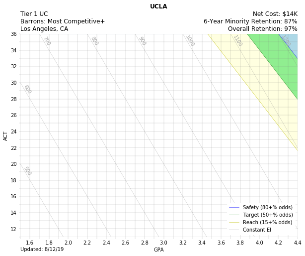

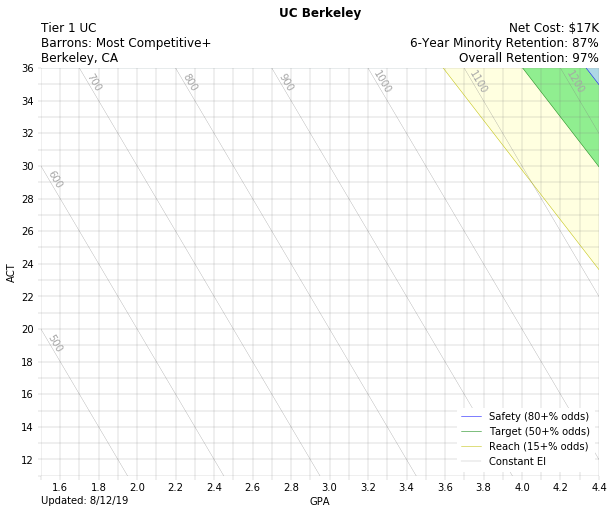

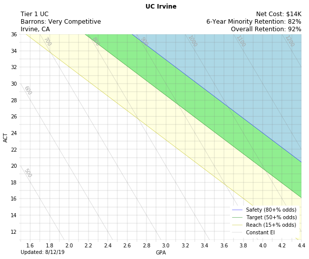

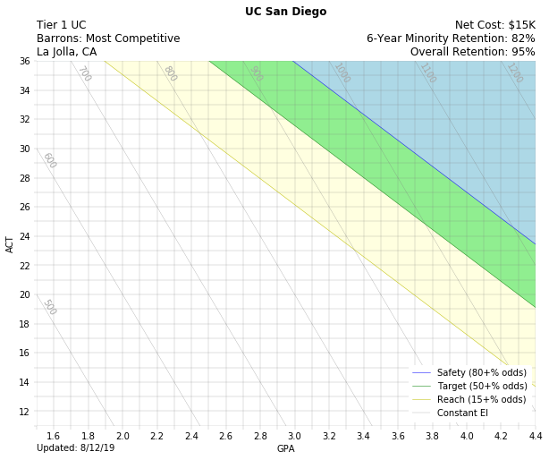

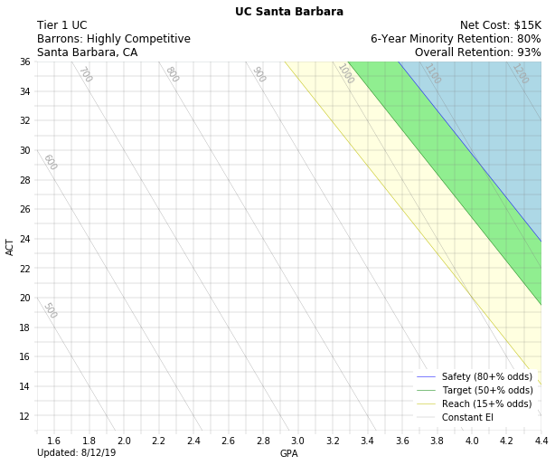

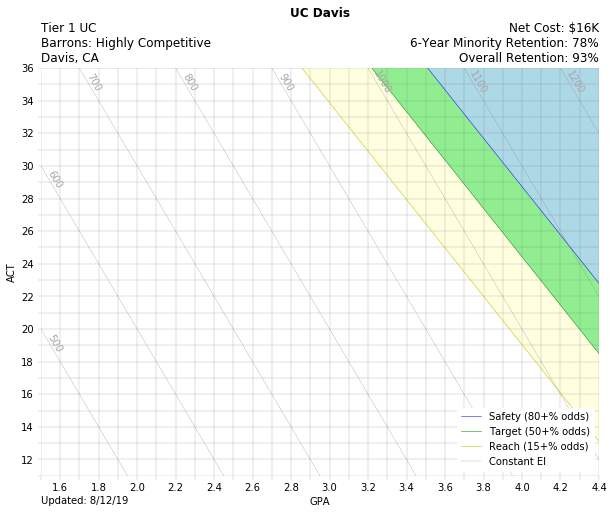

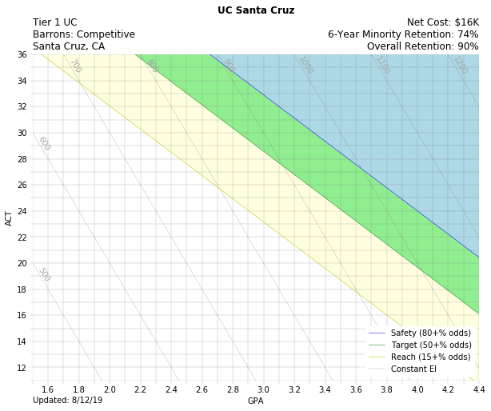

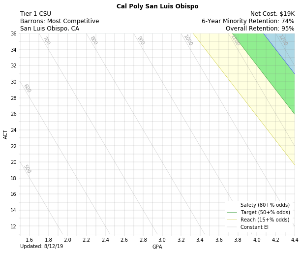

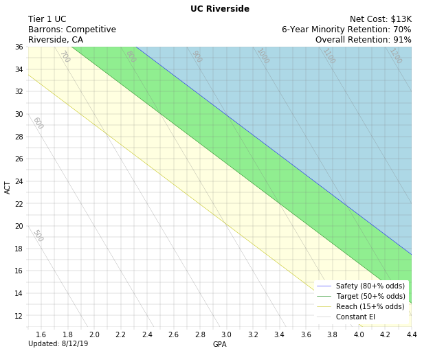

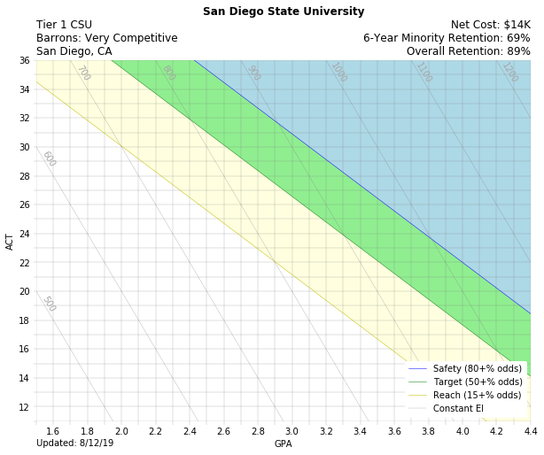

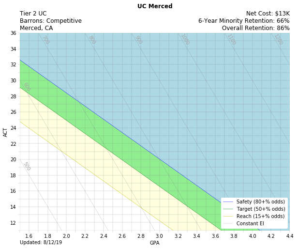

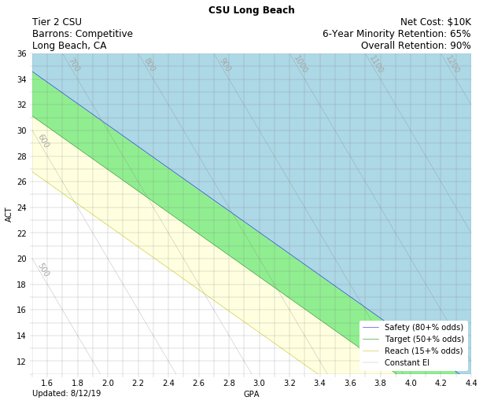

[20 more figures not shown]

```python
for university in c.index:
    save_figure(university)
```

```python
#    act_adj = c.loc[university]['ACT_adj']
#    act_coef = c.loc[university]['ACT_coef']

#    Convert the equation such that it is comparable to the EI = 10*ACT + 200*GPA
#    scalar = 10/act_coef
#    act_coef *= scalar
#    intercept = -1 * c.loc[university]['Intercept'] * scalar
#    gpa_coef = c.loc[university]['GPA_coef'] * scalar

#    equation = "%.1f = %.1f*GPA+%.1f*(ACT-%d)" % (intercept,gpa_coef,act_coef,act_adj)
#    equation = "KIPP EI = {0:.2f}*GPA+{0:.2f}*(ACT-{0:.2f})+{0:.2f}".format(gpa_coef,
#    act_coef,act_adj,intercept)
#    plt.annotate(equation,
#                 (0,0), (0, -20), xycoords='axes fraction',
#                 textcoords='offset points', va='top')
```

$$Logit_{Harvard}=GPA_{coef}*GPA + ACT_{coef}*(ACT-ACT_{adj})+intercept$$

$$ACT = ACT_{adj} + \frac{logit - intercept - (GPA_{coef})(GPA)}{ACT_{coef}}$$